# Statistique inférentielle - TD 1

Outils de surveillance et analyses statistiques

INTECHMER - CT3 GEM

## Données `tips`

Dans cette séance, nous allons utiliser les données `tips`, contenant des informations recueillies par un serveur pendant son travail. Les voici présentées ci-dessous (les 6 premières lignes).

```r
library(tidyverse)
library(knitr)
tips = read_csv("tips.csv")
kable(head(tips))
```

| total_bill | tip | sex | smoker | day | time | size |
| --- | --- | --- | --- | --- | --- | --- |
| 16.99 | 1.01 | Female | No | Sun | Dinner | 2 |
| 10.34 | 1.66 | Male | No | Sun | Dinner | 3 |
| 21.01 | 3.50 | Male | No | Sun | Dinner | 3 |
| 23.68 | 3.31 | Male | No | Sun | Dinner | 2 |
| 24.59 | 3.61 | Female | No | Sun | Dinner | 4 |
| 25.29 | 4.71 | Male | No | Sun | Dinner | 4 |

## Test de normalité

Lorsqu’on réalise une description des variables quantitatives, une des questions à se poser est la *normalité* de la variable. Dans le cas de données, puisque c’est la variable d’intérêt, on peut se poser la question suivante :

> La variable `total_bill` suit-elle une loi normale ?

### Visuellement

Premier graphique à créer, l’histogramme permet d’avoir un premier élément de réponse.

> La distribution semble unimodale (un seul *pic*) mais pas totale symétrique.

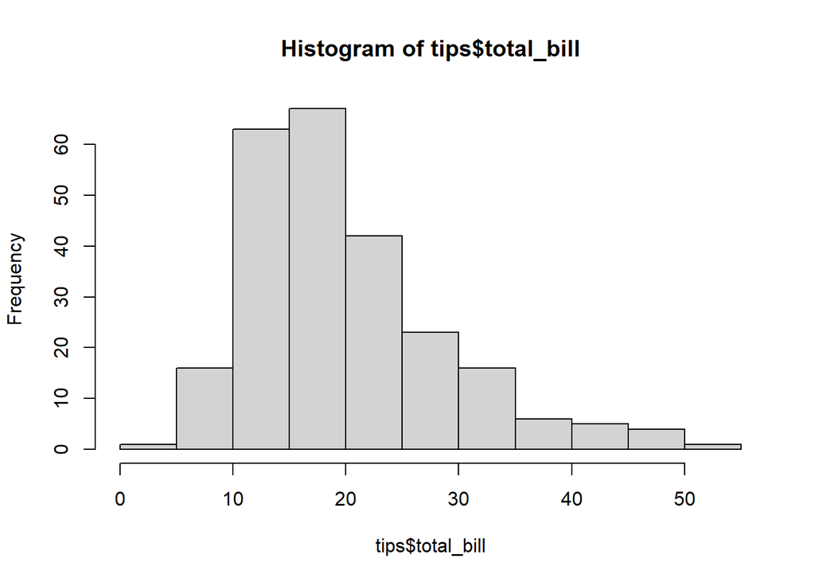

```r
hist(tips$total_bill)
```

Pour avoir une meilleure estimation de la distribution de la variable, il est d’usage de représenter une estimation par noyau de la densité, comme ci-dessous. L’intérêt est que cette représentation est moins sensible qu’un histogramme, dont l’allure peut changer en fonction du nombre d’intervalles choisi.

> On fait la même observation que ci-dessus.

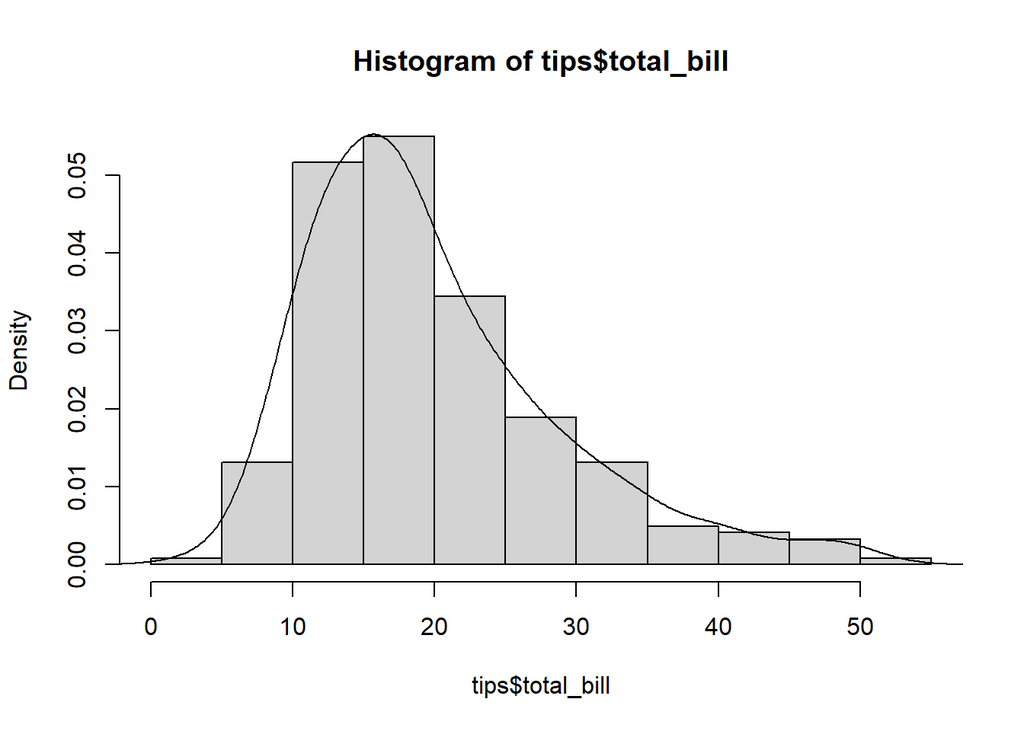

```r
hist(tips$total_bill, freq = F)
lines(density(tips$total_bill))
```

Mais le meilleur moyen est de réaliser ce qu’on appelle un **Q-Q plot**. Ce graphique présente les valeurs observées (en $Y$) pour les quantiles, versus les valeurs théoriques d’une loi Normale. Si les points suivent la droite, il y a normalité, sinon, on s’en éloigne.

> On remarque que la variable `total_bill` ne suit pas la droite.

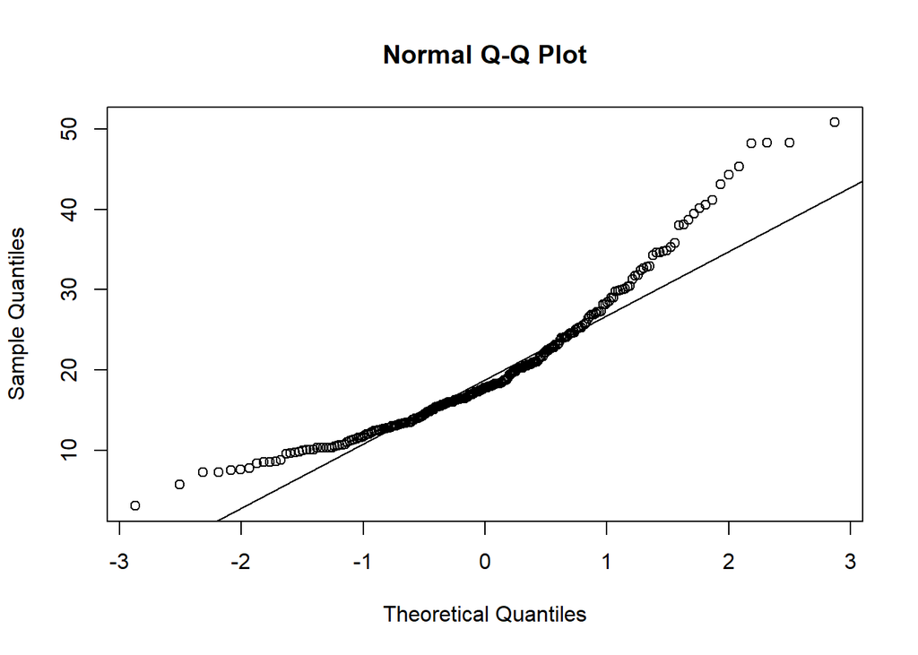

```r
qqnorm(tips$total_bill) # représentation des observés
qqline(tips$total_bill) # affichage de la droite, représentant la "normalité"
```

### Via un test statistique - Test de *Shapiro-Wilk*

La question peut se résoudre formellement à l’aide d’un *test statistique*, ici le **test de Shapiro-Wilk**. Celui-ci oppose deux hypothèses :

- **[$H_0$]** : la variable suit une loi Normale (on parle d’*hypothèse nulle*)
- **[$H_1$]** : la variable ne suit pas une loi Normale (*hypothèse alternative*)

Pour tous les tests que nous verrons par la suite, le fonctionnement d’un test est le suivant :

1. La fonction utilisée (ici `shapiro.test()`) calculera la probabilité d’être dans l’hypothèse $H_0$ au vu de ce qui est observé. Cette probabilité, $p(H_0)$, est appelé *p-value* ;
2. On compare cette valeur avec un seuil défini en amont, très souvent 5%, mais potentiellement plus (parfois 10%) ou moins (parfois 1%, voire 1‰) ;
3. La décision sera la suivante, selon le résultat de la comparaison :
- Si la *p-value* est inférieure au seuil choisi, on conclue que, la situation observée ayant peu de chances de l’être au vu de notre hypothèse $H_0$, celle-ci est fausse (on dit qu’elle est *rejetée*);
- Si la *p-value* est supérieure, on ne peut rejetter l’hypothèse nulle.

Voici donc son utilisation sur le montant total de la facture.

> On en conlue que la variable ne suit pas une loi normale (la *p-value* étant largement inférieure à 0.001).

```r
shapiro.test(tips$total_bill)
```

```
##
##  Shapiro-Wilk normality test
##
## data:  tips$total_bill
## W = 0.91972, p-value = 3.325e-10
```

### Exercice à faire

Tester la normalité de la variable `tip`, en produisant les graphiques nécessaires.

## Test de comparaison

Dans la suite, nous allons voir deux cas spécifiques de comparaison, pour lesquels le test utilisé est le même :

- Comparaison d’un ensemble de valeurs à une valeur spécifique ;
- Comparaison de deux ensembles de valeurs entre elle.

Dans ces deux cas, deux tests seront possibles :

- **Test de Students** (nommé aussi $t$-test) : test dit paramétrique, avec comme hypothèse que la ou les variables suivent une loi Normale (fonction `t.test()`);
- **Test de Wilcoxon** (nommé aussi de *Mann-Whitney* dans le deuxième cas) : test dit non-paramétrique, car ne posant aucune hypothèse sur les variables (fonction `wilcox.test()`)
  - on parle aussi de test des rangs.

L’usage de l’un ou l’autre test dépend donc de la normalité des variables. Cependant, le Théorème Central Limite (*TCL*, qui affine la loi des grands nombres) permet de justifier l’usage du premier dès que $n$ est grand.

### A une valeur spécifique

Ce cas est utilisée dès qu’on a une idée de la moyenne que doit prendre la variable. Par exemple, cela peut être utile lorsqu’on souhaite vérifier qu’un échantillon est représentatif par exemple.

Imaginons que notre serveur pense que le montant total est de 18$ en moyenne (parce qu’on lui a dit cela par exemple). Nous allons utiliser les deux tests pour se décider. Dans les deux fonctions, les hypothèses par défaut sont les suivantes :

- **[$H_0$]** : la variable a une espérance de 0
- **[$H_1$]** : la variable a une espérance différente de 0

Il est possible de définir deux éléments :

- la valeur de référence (par défaut égal à 0), avec le paramètre `mu` ;
- l’hypothèse alternative avec le paramètre `alternative` :
  - *des deux cotés* (valeur par défaut – `"two-sided"`) $\rightarrow$ on teste juste la différence ;
  - *plus faible* (valeur `"less"`) $\rightarrow$ valeur observée inférieure à la référence ;
  - *plus élevée* (valeur `"greater"`) $\rightarrow$ valeur observée supérieure à la référence.

> Si l’on suit le résultat fourni par le $t$-test, avec un risque d’erreur à 5%, nous conluons que le montant moyen est différent de 18. Alors qu’avec le test de Wilcoxon, nous ne pouvons pas rejeter l’hypothèse nulle, et donc concluons qu’il n’y a pas de différence.

```r
t.test(tips$total_bill, mu = 18)
```

```
##
##  One Sample t-test
##
## data:  tips$total_bill
## t = 3.1337, df = 243, p-value = 0.001938
## alternative hypothesis: true mean is not equal to 18
## 95 percent confidence interval:
##  18.66333 20.90855
## sample estimates:
## mean of x
##  19.78594
```

```r
wilcox.test(tips$total_bill, mu = 18)
```

```
##
##  Wilcoxon signed rank test with continuity correction
##
## data:  tips$total_bill
## V = 16425, p-value = 0.1802
## alternative hypothesis: true location is not equal to 18
```

> Si l’on change l’hypothèse alternative, en cherchant à savoir si la valeur est supérieure à 18, comme le laisse penser la moyenne calculée, nous obtenons les conclusions suivantes : - Le $t$-test nous indique que nous rejetons l’hypothèse nulle et donc la moyenne est bien supérieure à 18, avec un seuil de 5% (voire même de 1%) ; - Si on prend un seuil de 10%, le test de Wilcoxon permet de conclure que la moyenne est supérieure à 18 aussi.

```r
t.test(tips$total_bill, mu = 18, alternative = "greater")
```

```
##
##  One Sample t-test
##
## data:  tips$total_bill
## t = 3.1337, df = 243, p-value = 0.0009692
## alternative hypothesis: true mean is greater than 18
## 95 percent confidence interval:
##  18.84492      Inf
## sample estimates:
## mean of x
##  19.78594
```

```r
wilcox.test(tips$total_bill, mu = 18, alternative = "greater")
```

```
##
##  Wilcoxon signed rank test with continuity correction
##
## data:  tips$total_bill
## V = 16425, p-value = 0.0901
## alternative hypothesis: true location is greater than 18
```